Fuente código: Coursera, código mejorado y usado por Fernando Gutiérrez - Curso de Mineria de datos UCC-2023-2.

# Analizando los datos

[output not shown]

```python
pip install missingno
```

```python
#Importar librerias

import pandas as pd # módulo para tratamiento de datos
import numpy as np # módulo para tratamiento de matrices
import missingno as msno # librería para tratamiento de datos perdidos
import matplotlib.pyplot as plt # módulo graficador
import seaborn as sns
%matplotlib inline

import warnings
warnings.filterwarnings('ignore')
```

```python
# Informacion de los Datos fraude financiero dataset
data = pd.read_csv("data_FraudDetection_JAR2020.csv")
data.sample(10)
```

|  | fyear | gvkey | p_aaer | misstate | act | ap | at | ceq | che | cogs | ... | soft_assets | ch_cs | ch_cm | ch_roa | issue | bm | dpi | reoa | EBIT | ch_fcf |
| --- | --- | --- | --- | --- | --- | --- | --- | --- | --- | --- | --- | --- | --- | --- | --- | --- | --- | --- | --- | --- | --- |
| 62573 | 2000 | 31467 | 2172.0 | 1 | 322.428 | 131.228 | 380.868 | 159.102 | 2.656 | 1053.543 | ... | 0.963103 | 0.155848 | 0.482032 | 0.017140 | 1 | 1.420355 | 0.586517 | 0.226777 | 0.064584 | 0.109557 |
| 144390 | 2014 | 162934 | NaN | 0 | 2.058 | 0.433 | 4.591 | 4.158 | 1.735 | 1.079 | ... | 0.230233 | -0.545024 | 3.022730 | -0.155750 | 1 | 0.189249 | 0.845063 | -11.656720 | -1.189283 | 0.268384 |
| 115445 | 2009 | 63018 | NaN | 0 | 1.884 | 0.349 | 2.353 | -1.510 | 0.948 | 1.787 | ... | 0.414790 | -0.197101 | 0.155387 | 0.534356 | 0 | -0.314751 | 1.326490 | -26.068423 | -0.804505 | 2.248588 |
| 114455 | 2009 | 20523 | NaN | 0 | 0.918 | 0.226 | 5.620 | 2.461 | 0.154 | 6.854 | ... | 0.135943 | -0.514050 | -0.263608 | 0.048636 | 0 | 4.937457 | 0.902729 | 0.003203 | -0.019929 | 0.152886 |
| 44576 | 1997 | 64491 | NaN | 0 | 6.013 | 11.678 | 67.875 | 36.921 | 5.005 | 18.445 | ... | 0.029908 | 1.730325 | 0.114264 | 0.084415 | 1 | 1.455015 | 2.799903 | -0.014630 | 0.021201 | -0.832070 |
| 66495 | 2001 | 8638 | NaN | 0 | 95.985 | 19.293 | 426.240 | 81.525 | 7.792 | 226.182 | ... | 0.956501 | -0.065665 | -0.805183 | 0.034124 | 1 | 0.194677 | 0.908168 | -0.091014 | -0.043579 | 0.130201 |
| 35883 | 1996 | 25984 | NaN | 0 | 20.820 | 5.415 | 27.804 | -2.000 | 1.345 | 35.959 | ... | 0.820925 | 0.327074 | 0.167609 | -0.143356 | 1 | -0.026008 | 0.623857 | -0.444720 | -0.132859 | 0.516082 |
| 53875 | 1999 | 12834 | NaN | 0 | 0.956 | 0.342 | 4.353 | -0.691 | 0.116 | 1.292 | ... | 0.892488 | 0.584481 | 0.019030 | 0.299708 | 1 | -0.392975 | 0.608178 | -15.070756 | -1.461291 | 1.705025 |
| 110768 | 2008 | 110166 | NaN | 0 | 112.086 | 14.739 | 259.208 | 145.773 | 98.925 | 9.666 | ... | 0.067359 | 9.600000 | -2.834200 | 0.114326 | 1 | 0.949264 | 0.440893 | 0.139517 | 0.431052 | -0.044454 |
| 133236 | 2012 | 170750 | NaN | 0 | 50.275 | 34.224 | 606.701 | 462.068 | 26.358 | 20.908 | ... | 0.043021 | 0.803600 | -0.139962 | -0.082728 | 1 | 0.653385 | 1.530459 | -0.085831 | 0.036248 | -0.849445 |

10 rows × 46 columns

# Tamaño del dataset

```python
data.shape
```

```
(146045, 46)
```

# Información datos

```python
data.info()
```

```
<class 'pandas.core.frame.DataFrame'>
RangeIndex: 146045 entries, 0 to 146044
Data columns (total 46 columns):
 #   Column       Non-Null Count   Dtype
---  ------       --------------   -----
 0   fyear        146045 non-null  int64
 1   gvkey        146045 non-null  int64
 2   p_aaer       964 non-null     float64
 3   misstate     146045 non-null  int64
 4   act          146045 non-null  float64
 5   ap           146045 non-null  float64
 6   at           146045 non-null  float64
 7   ceq          146045 non-null  float64
 8   che          146045 non-null  float64
 9   cogs         146045 non-null  float64
```

[output cut: 38 more lines]

# Informe estadístico

```python
# Empezamos realizando un análisis descriptivo de las variables para entender sus dimensiones
data.describe()
```

|  | fyear | gvkey | p_aaer | misstate | act | ap | at | ceq | che | cogs | ... | soft_assets | ch_cs | ch_cm | ch_roa | issue | bm | dpi | reoa | EBIT | ch_fcf |
| --- | --- | --- | --- | --- | --- | --- | --- | --- | --- | --- | --- | --- | --- | --- | --- | --- | --- | --- | --- | --- | --- |
| count | 146045.000000 | 146045.000000 | 964.000000 | 146045.000000 | 146045.000000 | 146045.000000 | 146045.000000 | 146045.000000 | 146045.000000 | 146045.000000 | ... | 145453.000000 | 130127.000000 | 128938.000000 | 133367.000000 | 146045.000000 | 146027.000000 | 136817.000000 | 145454.000000 | 145454.000000 | 140638.000000 |
| mean | 2002.011702 | 54243.435516 | 2503.840249 | 0.006601 | 737.847759 | 181.993488 | 2374.041576 | 887.126243 | 218.657186 | 1302.280756 | ... | 0.499790 | 0.185169 | -0.090980 | -0.010208 | 0.863487 | 0.466137 | 1.042207 | -3.191197 | -0.238754 | -0.008842 |
| std | 6.959894 | 59937.455765 | 912.093250 | 0.080976 | 3744.542368 | 1047.546104 | 11957.736980 | 5056.948150 | 1330.490185 | 7870.665783 | ... | 0.274129 | 1.383354 | 2.844807 | 0.379574 | 0.343333 | 1.314661 | 0.495286 | 12.932219 | 1.059134 | 0.548216 |
| min | 1990.000000 | 1004.000000 | 371.000000 | 0.000000 | -0.254000 | 0.000000 | 0.000000 | -25560.000000 | -34.000000 | -366.645000 | ... | 0.004515 | -6.484197 | -17.359699 | -1.671565 | 0.000000 | -7.034304 | 0.151757 | -89.013245 | -7.016393 | -2.980601 |
| 25% | 1996.000000 | 10658.000000 | 1803.000000 | 0.000000 | 8.277000 | 1.151000 | 18.281000 | 6.337000 | 1.144000 | 6.795000 | ... | 0.270023 | -0.073635 | -0.260164 | -0.058635 | 1.000000 | 0.191546 | 0.854248 | -0.894633 | -0.128135 | -0.123402 |
| 50% | 2002.000000 | 25088.000000 | 2620.500000 | 0.000000 | 47.501000 | 6.462000 | 105.346000 | 47.308000 | 9.373000 | 53.382000 | ... | 0.524640 | 0.067918 | -0.023205 | -0.001893 | 1.000000 | 0.442172 | 0.974302 | -0.008046 | 0.043701 | -0.026155 |
| 75% | 2008.000000 | 66586.000000 | 3180.000000 | 0.000000 | 249.832000 | 42.259000 | 672.929000 | 271.547000 | 60.286000 | 372.730000 | ... | 0.726663 | 0.250237 | 0.139960 | 0.042188 | 1.000000 | 0.805320 | 1.097582 | 0.229724 | 0.108059 | 0.062294 |
| max | 2014.000000 | 317264.000000 | 3996.000000 | 1.000000 | 152629.000000 | 39903.000000 | 410074.000000 | 284434.000000 | 85709.000000 | 435726.253000 | ... | 0.993599 | 9.600000 | 16.573810 | 1.621628 | 1.000000 | 4.937457 | 4.036458 | 0.784573 | 0.550619 | 4.061810 |

8 rows × 46 columns

# Revisar Fraude

```python
#Contar tipo de fraudes
data.gvkey.value_counts()
```

```
2049      25
9919      25
6335      25
15291     25
6334      25
          ..
138346     1
189557     1
20147      1
165113     1
20798      1
Name: gvkey, Length: 18444, dtype: int64
```

```python
#comprobando cuantos fraudes hay
data['misstate'].value_counts()
```

```
0    145081
1       964
Name: misstate, dtype: int64
```

[figure not shown]

```python
# checking the no. of frauds in the dataset
data['misstate'].value_counts()

# plotting a pie chart to represent the fraction of the frauds

size = [2762196, 8213]
labels = ['NON-FRAUD', 'FRAUD']
colors = ['lightblue', 'yellow']
explode = [0, 0.2]

plt.pie(size, labels=labels, colors=colors, explode=explode, shadow=True, autopct='%.2f%%')
plt.title('Frauds v/s Non-Frauds', fontsize=20)
plt.axis('off')
plt.legend()
plt.show()
```

# Verificar valores nulos

Matrix missing: Mostramos una matriz de calor para visualizar las variables con mayor presencia de valores perdidos. Las líneas blancas indican los valores faltantes en cada columna.

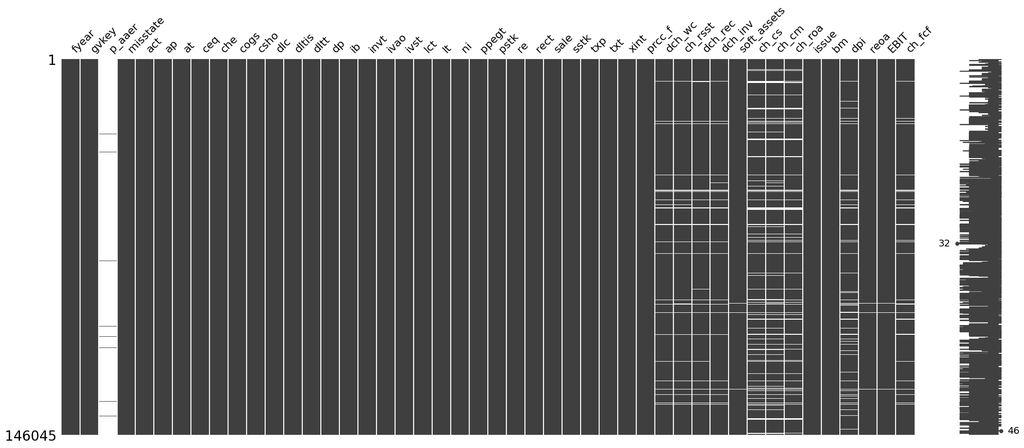

```python
# matrix missing
msno.matrix(data)
```

```python
#Verifico los datos faltantes del dataset o nulos
data.isnull().sum()
```

```
fyear               0
gvkey               0
p_aaer         145081
misstate            0
act                 0
ap                  0
at                  0
ceq                 0
che                 0
cogs                0
csho                0
dlc                 0
dltis               0
dltt                0
dp                  0
ib                  0
invt                0
ivao                0
ivst                0
lct                 0
lt                  0
ni                  0
ppegt               0
pstk                0
re                  0
rect                0
sale                0
sstk                0
txp                 0
txt                 0
xint                0
prcc_f              0
dch_wc           4759
ch_rsst          4851
dch_rec          4743
dch_inv          4615
soft_assets       592
ch_cs           15918
ch_cm           17107
ch_roa          12678
issue               0
bm                 18
dpi              9228
reoa              591
EBIT              591
ch_fcf           5407
dtype: int64
```

```python
# explorando la cantidad de valores perdidos en las variables
data.isna().sum()/data.shape[0]*100
```

```
fyear           0.000000
gvkey           0.000000
p_aaer         99.339929
misstate        0.000000
act             0.000000
ap              0.000000
at              0.000000
ceq             0.000000
che             0.000000
cogs            0.000000
csho            0.000000
dlc             0.000000
dltis           0.000000
dltt            0.000000
dp              0.000000
ib              0.000000
invt            0.000000
ivao            0.000000
ivst            0.000000
lct             0.000000
lt              0.000000
ni              0.000000
ppegt           0.000000
pstk            0.000000
re              0.000000
rect            0.000000
sale            0.000000
sstk            0.000000
txp             0.000000
txt             0.000000
xint            0.000000
prcc_f          0.000000
dch_wc          3.258585
ch_rsst         3.321579
dch_rec         3.247629
dch_inv         3.159985
soft_assets     0.405355
ch_cs          10.899380
ch_cm          11.713513
ch_roa          8.680886
issue           0.000000
bm              0.012325
dpi             6.318600
reoa            0.404670
EBIT            0.404670
ch_fcf          3.702284
dtype: float64
```

Columna "p_aaer": Esta columna tiene un alto porcentaje de valores perdidos (99.34%). Dado que la mayoría de los datos en esta columna son valores perdidos, es posible que desees considerar eliminarla por completo, ya que es poco probable que proporcione información útil para tu análisis.

Columnas con Valores Perdidos Moderados: Algunas columnas, como "dch_wc", "ch_rsst", "dch_rec", "dch_inv", "ch_cs", "ch_cm", "ch_roa" y "ch_fcf", tienen porcentajes moderados de valores perdidos que oscilan entre el 3% y el 11%. Puedes considerar diferentes enfoques para manejar estos valores perdidos, como la imputación, dependiendo de la importancia de estas columnas para tu análisis.

Otras Columnas: Las columnas restantes no tienen valores perdidos o tienen porcentajes muy bajos de valores perdidos.

```python
data.isin([0]).sum()
```

```
fyear               0
gvkey               0
p_aaer              0
misstate       145081
act               847
ap               1403
at                591
ceq                78
che              4774
cogs             8302
csho               18
dlc             35443
dltis           71251
dltt            39430
dp               4401
ib                133
invt            39785
ivao            97276
ivst            92420
lct               145
lt                126
ni                 63
ppegt            3884
pstk           125026
re                154
rect             7333
sale            10402
sstk            39246
txp             86648
txt             35309
xint            16568
prcc_f              3
dch_wc            108
ch_rsst            37
dch_rec          5203
dch_inv         35388
soft_assets         0
ch_cs              84
ch_cm             137
ch_roa              4
issue           19937
bm                 76
dpi                 0
reoa              149
EBIT               25
ch_fcf             16
dtype: int64
```

Al revisar los datos por sumas de ceros, observamos columnas de datos que pueden presentar ceros en su caracterización, por lo cual debemos establecer una política para lidiar con estos.

# Eliminar columnas

La variable "gvkey" identificador del fraude

La variable "p_aaer" se utiliza para gestionar el problema del fraude en serie. El fraude contable puede abarcar varios períodos consecutivos de presentación de informes, creando una situación del llamado “fraude en serie”

fyear año del fraude

misstate etiqueta que identifica el fraude: cero (no fraude) y uno (fraude)

```python
data = data.drop(['gvkey', 'p_aaer', 'fyear'], axis='columns')
data.head(10)
```

|  | misstate | act | ap | at | ceq | che | cogs | csho | dlc | dltis | ... | soft_assets | ch_cs | ch_cm | ch_roa | issue | bm | dpi | reoa | EBIT | ch_fcf |
| --- | --- | --- | --- | --- | --- | --- | --- | --- | --- | --- | --- | --- | --- | --- | --- | --- | --- | --- | --- | --- | --- |
| 0 | 0 | 10.047 | 3.736 | 32.335 | 6.262 | 0.002 | 30.633 | 2.526 | 3.283 | 32.853 | ... | 0.312448 | 0.095082 | 0.082631 | -0.019761 | 1 | 0.413170 | 0.873555 | 0.167620 | 0.161961 | -0.042140 |
| 1 | 0 | 1.247 | 0.803 | 7.784 | 0.667 | 0.171 | 1.125 | 3.556 | 0.021 | 2.017 | ... | 0.315904 | 0.188832 | -0.211389 | -0.117832 | 1 | 0.157887 | 0.745139 | -0.428957 | -0.157888 | 0.100228 |
| 2 | 0 | 55.040 | 3.601 | 118.120 | 44.393 | 3.132 | 107.343 | 3.882 | 6.446 | 6.500 | ... | 0.605342 | 0.097551 | -0.105780 | 0.091206 | 1 | 2.231337 | 1.015131 | 0.394768 | 0.063681 | 0.066348 |
| 3 | 0 | 24.684 | 3.948 | 34.591 | 7.751 | 0.411 | 31.214 | 4.755 | 8.791 | 0.587 | ... | 0.793068 | -0.005725 | -0.249704 | 0.017545 | 1 | 1.043582 | 1.026261 | 0.094822 | 0.088347 | -0.017358 |
| 4 | 0 | 17.325 | 3.520 | 27.542 | -12.142 | 1.017 | 32.662 | 6.735 | 32.206 | 0.000 | ... | 0.869182 | -0.231536 | -1.674893 | -0.466667 | 0 | -1.602508 | 0.598443 | -0.942379 | -0.700821 | 0.130349 |
| 5 | 0 | 148.396 | 24.301 | 328.495 | 111.015 | 8.478 | 153.262 | 11.235 | 44.339 | 0.273 | ... | 0.688689 | 0.040056 | 0.092675 | 0.003067 | 1 | 0.389406 | 0.851688 | 0.191741 | 0.105527 | -0.034367 |
| 6 | 0 | 637.880 | 199.012 | 1011.901 | 324.132 | 113.271 | 1185.288 | 28.489 | 22.444 | 60.769 | ... | 0.754448 | -0.033881 | -0.372440 | -0.040405 | 1 | 1.379084 | 0.955720 | -0.038167 | 0.055174 | -0.042160 |
| 7 | 0 | 396.594 | 92.140 | 677.736 | 183.566 | 50.125 | 596.137 | 46.758 | 80.971 | 1.146 | ... | 0.819713 | 0.047023 | -0.061932 | -0.108796 | 1 | 1.847471 | 0.964188 | -0.192385 | -0.031264 | -0.041039 |
| 8 | 0 | 2657.800 | 966.300 | 13353.600 | 3727.400 | 949.300 | 10908.200 | 62.300 | 1319.100 | 2264.600 | ... | 0.243882 | 0.117693 | -0.369057 | -0.047424 | 1 | 1.236793 | 0.996031 | 0.181389 | 0.022773 | -0.038199 |
| 9 | 0 | 0.004 | 0.000 | 0.126 | -0.778 | 0.000 | 0.000 | 9.928 | 0.624 | 0.132 | ... | 0.809524 | NaN | NaN | -1.520085 | 1 | -0.156728 | NaN | -22.174603 | -7.016393 | 0.118902 |

10 rows × 43 columns

# Técnicas de imputación de datos

Imputación Basada en Reglas de Negocio: Reemplazar los valores faltantes con cero

```python
# Lista de las columnas que tienen valores perdidos
columnas_imputar = ['dch_wc', 'ch_rsst', 'dch_rec', 'dch_inv', 'ch_cs', 'ch_cm', 'ch_roa', 'bm', 'reoa', 'EBIT', 'ch_fcf', 'soft_assets', 'dpi']
#Reemplazar los valores nulos con -1 en las columnas seleccionados
data[columnas_imputar] = data[columnas_imputar].fillna(0)
```

```python
# Después de la imputación
print(data[columnas_imputar].isnull().sum())
```

```
dch_wc         0
ch_rsst        0
dch_rec        0
dch_inv        0
ch_cs          0
ch_cm          0
ch_roa         0
bm             0
reoa           0
EBIT           0
ch_fcf         0
soft_assets    0
dpi            0
dtype: int64
```

```python
# Itera a través de las columnas del DataFrame y verifica el equilibrio
for columna in data.columns:
    if data[columna].dtype == 'object':
        # Si es una variable categórica, verifica el equilibrio de las categorías
        counts = data[columna].value_counts()
        print(f"Variable categórica: {columna}")
        print(counts)
    elif data[columna].dtype in ['int64', 'float64']:
        # Si es una variable numérica, puedes calcular estadísticas descriptivas
        descripcion = data[columna].describe()
        print(f"Variable numérica: {columna}")
        print(descripcion)
    print('-' * 40)
```

```
Variable numérica: misstate
count    146045.000000
mean          0.006601
std           0.080976
min           0.000000
25%           0.000000
50%           0.000000
75%           0.000000
max           1.000000
Name: misstate, dtype: float64
----------------------------------------
Variable numérica: act
count    146045.000000
mean        737.847759
std        3744.542368
min          -0.254000
25%           8.277000
50%          47.501000
75%         249.832000
max      152629.000000
Name: act, dtype: float64
----------------------------------------
Variable numérica: ap
count    146045.000000
mean        181.993488
std        1047.546104
min           0.000000
25%           1.151000
50%           6.462000
75%          42.259000
max       39903.000000
Name: ap, dtype: float64
----------------------------------------
Variable numérica: at
count    146045.000000
mean       2374.041576
std       11957.736980
min           0.000000
25%          18.281000
50%         105.346000
```

[output cut: 418 more lines]

```
75%           0.107747
max           0.550619
Name: EBIT, dtype: float64
----------------------------------------
Variable numérica: ch_fcf
count    146045.000000
mean         -0.008515
std           0.537974
min          -2.980601
25%          -0.116775
50%          -0.021442
75%           0.055781
max           4.061810
Name: ch_fcf, dtype: float64
----------------------------------------
```

```python
data.isna().sum()
```

```
misstate       0
act            0
ap             0
at             0
ceq            0
che            0
cogs           0
csho           0
dlc            0
dltis          0
dltt           0
dp             0
ib             0
invt           0
ivao           0
ivst           0
lct            0
lt             0
ni             0
ppegt          0
pstk           0
re             0
rect           0
sale           0
sstk           0
txp            0
txt            0
xint           0
prcc_f         0
dch_wc         0
ch_rsst        0
dch_rec        0
dch_inv        0
soft_assets    0
ch_cs          0
ch_cm          0
ch_roa         0
issue          0
bm             0
dpi            0
reoa           0
EBIT           0
ch_fcf         0
dtype: int64
```

# Mezclar el dataset

```python
#Mezclar el dataset
data = data.sample(frac=1).reset_index(drop=True)
data.head(10)
```

|  | misstate | act | ap | at | ceq | che | cogs | csho | dlc | dltis | ... | soft_assets | ch_cs | ch_cm | ch_roa | issue | bm | dpi | reoa | EBIT | ch_fcf |
| --- | --- | --- | --- | --- | --- | --- | --- | --- | --- | --- | --- | --- | --- | --- | --- | --- | --- | --- | --- | --- | --- |
| 0 | 0 | 86.905 | 2.055 | 131.700 | 82.346 | 15.200 | 123.989 | 17.182 | 25.000 | 0.000 | ... | 0.797980 | 0.011913 | -0.006535 | -0.032103 | 1 | 1.479189 | 1.325917 | 0.359081 | 0.110327 | -0.063188 |
| 1 | 0 | 9.932 | 3.023 | 11.920 | 4.409 | 1.647 | 22.471 | 12.077 | 1.609 | 0.000 | ... | 0.708221 | 2.154233 | 0.089975 | 0.544657 | 1 | 0.122098 | 0.921073 | -3.324497 | -0.778356 | 0.015223 |
| 2 | 0 | 6315.000 | 334.000 | 14379.000 | 5421.000 | 4747.000 | 823.000 | 698.000 | 997.000 | 996.000 | ... | 0.591835 | 0.001764 | -0.008561 | -0.035227 | 1 | 0.314687 | 1.027598 | -0.132068 | 0.080812 | 0.063287 |
| 3 | 0 | 128.184 | 65.720 | 137.464 | 39.874 | 0.856 | 449.454 | 6.756 | 23.569 | 0.000 | ... | 0.933997 | -0.014461 | 3.124296 | 0.072663 | 1 | 1.026437 | 1.977644 | 0.053068 | -0.012214 | 0.132986 |
| 4 | 0 | 6.875 | 0.086 | 7.961 | 7.813 | 6.714 | 0.000 | 7.317 | 0.000 | 0.000 | ... | 0.035423 | -1.048336 | 0.313200 | -0.010105 | 0 | 0.539287 | 0.691484 | -0.156011 | -0.065193 | -0.246235 |
| 5 | 0 | 244.012 | 15.551 | 522.537 | 437.628 | 107.564 | 196.961 | 38.535 | 0.000 | 0.000 | ... | 0.564245 | 0.062091 | 0.061302 | -0.186693 | 1 | 0.445009 | 0.797638 | 0.688198 | 0.049386 | -0.098841 |
| 6 | 0 | 643.673 | 91.094 | 1270.161 | 976.318 | 321.573 | 223.479 | 72.430 | 0.000 | 0.000 | ... | 0.739914 | 1.170488 | 1.236182 | -0.005702 | 1 | 1.739286 | 0.951196 | 0.169584 | 0.049256 | 0.018113 |
| 7 | 0 | 100.120 | 11.680 | 163.714 | 91.940 | 31.608 | 56.767 | 16.592 | 17.912 | 8.112 | ... | 0.571350 | 0.006168 | -0.036024 | 0.023087 | 1 | 0.694389 | 1.035122 | 0.144600 | 0.108586 | -0.013218 |
| 8 | 0 | 0.129 | 0.035 | 0.374 | 0.319 | 0.041 | 0.766 | 10.787 | 0.000 | 0.000 | ... | 0.644385 | 0.000000 | 0.000000 | 0.000000 | 1 | 0.067211 | 0.000000 | -4.521390 | -2.096257 | 0.000000 |
| 9 | 0 | 59.401 | 3.531 | 71.392 | 31.120 | 33.734 | 8.153 | 17.214 | 0.000 | 0.000 | ... | 0.437346 | -0.123475 | -0.110337 | -0.045219 | 1 | 0.556256 | 0.815782 | -0.037595 | -0.112310 | 0.151375 |

10 rows × 43 columns

## 2. Análisis de patrones de características individuales mediante visualización

- Para instalar seaborn usamos pip que es el administrador de paquetes de python.

### calcular la correlación entre variables de tipo “int64” o “float64” utilizando el método “corr”:

```python
corr = data.corr()
# Aplica un mapa de colores a la tabla
corr.style.background_gradient("RdYlGn", low=-1, high=1)

# Imprime la tabla
print(corr)
```

```
             misstate       act        ap        at       ceq       che  \
misstate     1.000000  0.022300  0.027725  0.021769  0.021051  0.015030
act          0.022300  1.000000  0.837398  0.878315  0.781781  0.824967
ap           0.027725  0.837398  1.000000  0.814882  0.714306  0.606061
at           0.021769  0.878315  0.814882  1.000000  0.922935  0.696252
ceq          0.021051  0.781781  0.714306  0.922935  1.000000  0.674905
che          0.015030  0.824967  0.606061  0.696252  0.674905  1.000000
cogs         0.019290  0.775588  0.893112  0.766761  0.688589  0.499444
csho         0.014707  0.380716  0.320160  0.422942  0.431327  0.387291
dlc          0.010195  0.756073  0.626860  0.732312  0.589192  0.504066
dltis        0.012666  0.443239  0.432536  0.502433  0.410146  0.295679
dltt         0.023159  0.704906  0.646234  0.869181  0.688693  0.540087
dp           0.012092  0.734202  0.727898  0.897125  0.828959  0.581175
ib          -0.001749  0.594168  0.561907  0.620597  0.664445  0.559258
invt         0.020917  0.786498  0.767760  0.695842  0.630951  0.481461
ivao         0.007711  0.527799  0.419550  0.493431  0.436267  0.446340
ivst         0.005238  0.531702  0.309106  0.398065  0.421553  0.825681
lct          0.019946  0.942648  0.886424  0.911807  0.779619  0.695049
lt           0.020593  0.873467  0.816551  0.966151  0.795434  0.655144
ni          -0.007021  0.555981  0.521918  0.580658  0.624362  0.530992
ppegt        0.010044  0.707443  0.737856  0.892599  0.819582  0.511092
pstk         0.003397  0.087006  0.087013  0.119306  0.071435  0.073945
re           0.003421  0.613358  0.601986  0.645504  0.715160  0.462425
rect         0.021312  0.921919  0.799190  0.824882  0.698456  0.627657
sale         0.019871  0.833866  0.909881  0.838974  0.765433  0.582301
sstk         0.028054  0.250608  0.173988  0.275601  0.286305  0.269170
txp          0.006423  0.567046  0.541236  0.638569  0.631110  0.459817
txt          0.007395  0.594196  0.627781  0.644187  0.665308  0.481826
xint         0.027066  0.581960  0.573818  0.776689  0.616064  0.447832
prcc_f       0.020197  0.149363  0.130508  0.140180  0.133828  0.127099
dch_wc       0.012899  0.009335  0.005334  0.006868  0.007288  0.001843
ch_rsst      0.014113  0.004418  0.002657  0.005809  0.014202  0.005860
dch_rec      0.023826 -0.005907 -0.003290 -0.012733 -0.009330 -0.009777
dch_inv      0.018623 -0.002950 -0.000248 -0.009488 -0.006022 -0.010534
soft_assets  0.040549  0.042000  0.031988  0.013128  0.005854  0.002620
ch_cs        0.012513 -0.008174 -0.007799 -0.007332 -0.004513 -0.004849
ch_cm       -0.000321  0.007281  0.006339  0.007360  0.006702  0.004926
ch_roa      -0.000616  0.004458  0.003628  0.003653  0.003698  0.005213
issue        0.023545  0.063094  0.056821  0.065528  0.056817  0.049545
bm           0.003516  0.010422  0.010727  0.016244  0.031305  0.004006
```

[output cut: 126 more lines]

```
ch_rsst      0.315202  0.438963 -0.690730
dch_rec      0.101144  0.119219 -0.175720
dch_inv      0.087829  0.099924 -0.163581
soft_assets  0.031555  0.050370  0.015568
ch_cs        0.047889  0.033019 -0.064673
ch_cm        0.020080  0.027951 -0.010531
ch_roa       0.146317  0.334876  0.135155
issue        0.144267  0.080323 -0.137191
bm           0.298402  0.239431 -0.196553
dpi          0.114768  0.134974 -0.076366
reoa         1.000000  0.732063 -0.349606
EBIT         0.732063  1.000000 -0.258254
ch_fcf      -0.349606 -0.258254  1.000000

[43 rows x 43 columns]
```

```python
# Visualizar la relación entre todas las variables utilizando una matriz de diagramas de dispersión
#sns.pairplot(data)
```

```python
#Guardamos el dataset- Hacemos una clasificacion binaria.
data.to_csv('fraude1.csv', index=False)
```

# Nuevo conjunto de datos fraude1

```python
data1 = pd.read_csv('fraude1.csv')
data1.sample(10)
```

|  | misstate | act | ap | at | ceq | che | cogs | csho | dlc | dltis | ... | soft_assets | ch_cs | ch_cm | ch_roa | issue | bm | dpi | reoa | EBIT | ch_fcf |
| --- | --- | --- | --- | --- | --- | --- | --- | --- | --- | --- | --- | --- | --- | --- | --- | --- | --- | --- | --- | --- | --- |
| 2276 | 0 | 49.843 | 9.312 | 87.157 | 46.298 | 17.339 | 153.188 | 7.723 | 2.229 | 0.000 | ... | 0.431015 | 0.104854 | 0.145423 | 0.078006 | 1 | 0.474837 | 0.969057 | 0.324185 | 0.206857 | 0.078132 |
| 75718 | 0 | 54.150 | 6.295 | 76.260 | 20.453 | 17.588 | 63.112 | 18.756 | 3.500 | 4.204 | ... | 0.549187 | 0.018030 | 0.046095 | -0.253444 | 1 | 0.429322 | 1.363474 | -0.086402 | -0.222030 | -0.244388 |
| 8658 | 0 | 24.156 | 13.001 | 94.800 | 67.685 | 0.000 | 101.773 | 7.019 | 0.000 | 0.000 | ... | 0.586762 | 0.101345 | 0.446849 | 0.033354 | 0 | 0.334134 | 1.133911 | -0.052405 | 0.162637 | -0.022435 |
| 88068 | 0 | 119.784 | 16.708 | 263.305 | 224.342 | 35.006 | 110.373 | 21.771 | 1.688 | 0.000 | ... | 0.515163 | 0.251402 | -0.069120 | -0.012476 | 1 | 0.445605 | 0.897153 | 0.364213 | 0.247830 | -0.299889 |
| 80108 | 0 | 61.601 | 9.795 | 121.167 | 55.069 | 16.181 | 133.179 | 9.066 | 6.177 | 42.000 | ... | 0.706975 | 0.153359 | -0.014990 | 0.011307 | 1 | 0.373799 | 1.073176 | 0.017926 | 0.109180 | -0.393225 |
| 41905 | 0 | 3.727 | 1.975 | 5.124 | 1.041 | 0.080 | 7.011 | 5.771 | 1.793 | 0.000 | ... | 0.804059 | 0.333333 | -0.762448 | -0.145783 | 1 | 0.144308 | 1.066272 | -0.519321 | -0.221116 | -0.632285 |
| 13640 | 0 | 648.889 | 232.113 | 1544.500 | 324.292 | 10.191 | 1775.247 | 43.891 | 8.883 | 1196.674 | ... | 0.697805 | 0.030609 | 0.078540 | 0.031105 | 1 | 1.048025 | 1.052823 | 0.196492 | 0.006058 | 0.110876 |
| 88471 | 0 | 154.989 | 5.920 | 306.915 | 196.000 | 71.853 | 53.867 | 24.218 | 0.000 | 0.000 | ... | 0.665715 | -0.608967 | 0.112160 | 0.110467 | 1 | 0.322925 | 1.008583 | 0.323673 | 0.045084 | -0.216890 |
| 119379 | 0 | 1.493 | 0.150 | 2.769 | 2.032 | 1.162 | 1.625 | 2.904 | 0.174 | 0.525 | ... | 0.336222 | -0.086218 | -0.363542 | -0.248944 | 1 | 0.399843 | 0.916249 | -1.983026 | -0.220296 | -0.299909 |
| 80071 | 0 | 279.770 | 92.840 | 825.780 | 61.980 | 9.480 | 566.830 | 33.896 | 20.390 | 1047.800 | ... | 0.792075 | -0.189759 | -0.039950 | 0.132088 | 1 | 0.270094 | 0.954388 | -0.565187 | 0.064424 | 0.159237 |

10 rows × 43 columns

```python
from sklearn.model_selection import train_test_split
```

```python
X= data1.drop('misstate', axis=1)
y = data1['misstate']
```

```python
#Ahora eempezamos a construir el modelo, separamos los datos de entrenamiento y pruebas
X_train, X_test, y_train, y_test = train_test_split(X, y, test_size = 0.30, random_state=42)
```

```python
X_train.info()
```

```
<class 'pandas.core.frame.DataFrame'>
Int64Index: 102231 entries, 83313 to 121958
Data columns (total 42 columns):
 #   Column       Non-Null Count   Dtype
---  ------       --------------   -----
 0   act          102231 non-null  float64
 1   ap           102231 non-null  float64
 2   at           102231 non-null  float64
 3   ceq          102231 non-null  float64
 4   che          102231 non-null  float64
 5   cogs         102231 non-null  float64
 6   csho         102231 non-null  float64
 7   dlc          102231 non-null  float64
 8   dltis        102231 non-null  float64
 9   dltt         102231 non-null  float64
```

[output cut: 34 more lines]

# Técnicas de escalado

La elección entre las técnicas de escalado de características como RobustScaler, StandardScaler y MinMaxScaler depende de la naturaleza de tus datos y los requisitos de tu modelo de machine learning. Cada técnica tiene sus propias características y es adecuada para diferentes situaciones. Aquí hay una guía general sobre cuándo usar cada una:

**RobustScaler**:

- *Cuándo usarlo*: Utiliza RobustScaler cuando tus datos contienen valores atípicos o anomalías. RobustScaler es resistente a los valores extremos y utiliza estadísticas robustas como la mediana y el rango intercuartílico para escalar los datos.
- *Ventajas*: Bueno para datos con valores atípicos, ya que no se ven afectados por ellos.
- *Consideraciones*: No restringe los datos a un rango específico como MinMaxScaler, por lo que los datos pueden tener una mayor dispersión.

**StandardScaler (Z-Score Scaling)**:

- *Cuándo usarlo*: Utiliza StandardScaler cuando tus datos sigan una distribución normal o aproximadamente normal. Es una opción sólida para muchas técnicas de machine learning, como regresión lineal, SVM y algoritmos basados en gradiente.
- *Ventajas*: Transforma los datos para que tengan una media de cero y una desviación estándar de uno, lo que puede ser beneficioso para algoritmos que asumen normalidad.
- *Consideraciones*: Puede verse afectado por valores atípicos y no es adecuado para datos que no siguen una distribución normal.

**MinMaxScaler**:

- *Cuándo usarlo*: Utiliza MinMaxScaler cuando desees que tus datos se escalen a un rango específico, generalmente entre 0 y 1. Es útil para algoritmos que requieren que los datos estén en un rango acotado, como las redes neuronales y los algoritmos de clustering basados en distancia.
- *Ventajas*: Escala los datos al rango deseado, lo que puede mejorar la convergencia en algunos algoritmos.
- *Consideraciones*: Sensible a valores atípicos si los valores extremos están presentes.

La elección de la técnica depende de la naturaleza de tus datos y del algoritmo que planeas usar. Aquí hay algunas pautas generales:

- Si tienes valores atípicos en tus datos y deseas ser resistente a ellos, considera RobustScaler.
- Si tus datos siguen una distribución normal y planeas utilizar algoritmos que asumen normalidad, elige StandardScaler.
- Si deseas que tus datos estén en un rango específico, como [0, 1], usa MinMaxScaler.

```python
pip install -U scikit-learn
```

# MinMaxScaler

```python
from sklearn import preprocessing
fraud_value = data1.copy().values
min_max_scaler = preprocessing.MinMaxScaler()
fraud_scaled = min_max_scaler.fit_transform(fraud_value)
fraud_df_scaled = pd.DataFrame(fraud_scaled, columns=data1.columns)
fraud_df_scaled
```

|  | misstate | act | ap | at | ceq | che | cogs | csho | dlc | dltis | ... | soft_assets | ch_cs | ch_cm | ch_roa | issue | bm | dpi | reoa | EBIT | ch_fcf |
| --- | --- | --- | --- | --- | --- | --- | --- | --- | --- | --- | --- | --- | --- | --- | --- | --- | --- | --- | --- | --- | --- |
| 0 | 0.0 | 0.000571 | 0.000051 | 0.000321 | 0.082719 | 0.000574 | 0.001125 | 0.000172 | 3.318065e-04 | 0.000104 | ... | 0.803121 | 0.403882 | 0.511387 | 0.497833 | 1.0 | 0.711131 | 0.328485 | 0.995262 | 0.941814 | 0.414263 |
| 1 | 0.0 | 0.000067 | 0.000076 | 0.000029 | 0.082467 | 0.000416 | 0.000892 | 0.000121 | 2.220955e-05 | 0.000104 | ... | 0.712784 | 0.537076 | 0.514231 | 0.672970 | 1.0 | 0.597774 | 0.228188 | 0.954241 | 0.824373 | 0.425398 |
| 2 | 0.0 | 0.041376 | 0.008370 | 0.035064 | 0.099941 | 0.055760 | 0.002728 | 0.006974 | 1.319694e-02 | 0.005379 | ... | 0.595648 | 0.403251 | 0.511328 | 0.496885 | 1.0 | 0.613861 | 0.254579 | 0.989792 | 0.937914 | 0.432222 |
| 3 | 0.0 | 0.000842 | 0.001647 | 0.000335 | 0.082582 | 0.000407 | 0.001871 | 0.000067 | 3.128662e-04 | 0.000104 | ... | 0.940015 | 0.402242 | 0.603651 | 0.529646 | 1.0 | 0.673313 | 0.489945 | 0.991854 | 0.925620 | 0.442120 |
| 4 | 0.0 | 0.000047 | 0.000002 | 0.000019 | 0.082478 | 0.000475 | 0.000841 | 0.000073 | 9.132653e-07 | 0.000104 | ... | 0.035651 | 0.337963 | 0.520810 | 0.504513 | 0.0 | 0.632621 | 0.171310 | 0.989526 | 0.918619 | 0.388271 |
| ... | ... | ... | ... | ... | ... | ... | ... | ... | ... | ... | ... | ... | ... | ... | ... | ... | ... | ... | ... | ... | ... |
| 146040 | 0.0 | 0.001118 | 0.000170 | 0.000692 | 0.082749 | 0.000542 | 0.001272 | 0.000093 | 7.580102e-05 | 0.001406 | ... | 0.748904 | 0.405876 | 0.511333 | 0.510309 | 1.0 | 0.619371 | 0.252351 | 0.992328 | 0.947732 | 0.420607 |
| 146041 | 0.0 | 0.000900 | 0.000801 | 0.000403 | 0.082734 | 0.000412 | 0.001976 | 0.000042 | 5.817897e-04 | 0.000104 | ... | 0.848090 | 0.403166 | 0.525276 | 0.500139 | 1.0 | 0.652830 | 0.247990 | 0.996553 | 0.943131 | 0.419101 |
| 146042 | 0.0 | 0.000053 | 0.000044 | 0.000036 | 0.082382 | 0.000435 | 0.000987 | 0.009826 | 6.915669e-05 | 0.000148 | ... | 0.758906 | 0.576344 | 0.503446 | 0.849762 | 1.0 | 0.037023 | 0.334787 | 0.908647 | 0.975436 | 0.518144 |
| 146043 | 0.0 | 0.000060 | 0.000145 | 0.000089 | 0.082470 | 0.000414 | 0.000870 | 0.000163 | 1.973183e-04 | 0.000112 | ... | 0.600967 | 0.383759 | 0.497978 | 0.608232 | 1.0 | 0.604356 | 0.319250 | 0.982495 | 0.905182 | 0.457174 |
| 146044 | 0.0 | 0.005189 | 0.003681 | 0.016939 | 0.086874 | 0.000432 | 0.004473 | 0.001082 | 3.058367e-03 | 0.004830 | ... | 0.382431 | 0.398850 | 0.510533 | 0.512149 | 1.0 | 0.650682 | 0.272759 | 0.990379 | 0.939156 | 0.424809 |

146045 rows × 43 columns

```python
fraud_df_scaled.info()
```

```
<class 'pandas.core.frame.DataFrame'>
RangeIndex: 146045 entries, 0 to 146044
Data columns (total 43 columns):
 #   Column       Non-Null Count   Dtype
---  ------       --------------   -----
 0   misstate     146045 non-null  float64
 1   act          146045 non-null  float64
 2   ap           146045 non-null  float64
 3   at           146045 non-null  float64
 4   ceq          146045 non-null  float64
 5   che          146045 non-null  float64
 6   cogs         146045 non-null  float64
 7   csho         146045 non-null  float64
 8   dlc          146045 non-null  float64
 9   dltis        146045 non-null  float64
```

[output cut: 35 more lines]

# RobustScaler

```python
from sklearn import preprocessing
fraud_value_1 = data1.copy().values
robust_scaler = preprocessing.RobustScaler()
fraud_scaled_1 = robust_scaler.fit_transform(fraud_value_1)
fraud_df_scaled_1 = pd.DataFrame(fraud_scaled_1, columns=data1.columns)
fraud_df_scaled_1
```

|  | misstate | act | ap | at | ceq | che | cogs | csho | dlc | dltis | ... | soft_assets | ch_cs | ch_cm | ch_roa | issue | bm | dpi | reoa | EBIT | ch_fcf |
| --- | --- | --- | --- | --- | --- | --- | --- | --- | --- | --- | --- | --- | --- | --- | --- | --- | --- | --- | --- | --- | --- |
| 0 | 0.0 | 0.163126 | -0.107205 | 0.040257 | 0.132114 | 0.098526 | 0.192950 | -0.103157 | 1.855046 | -0.002533 | ... | 0.598750 | -0.102854 | -0.021262 | -0.388379 | 0.0 | 1.689713 | 1.348153 | 0.327238 | 0.286562 | -0.241923 |
| 1 | 0.0 | -0.155530 | -0.083658 | -0.142712 | -0.161755 | -0.130635 | -0.084471 | -0.201444 | 0.019306 | -0.002533 | ... | 0.403417 | 8.000717 | 0.292755 | 6.589096 | 0.0 | -0.521341 | -0.149893 | -2.976094 | -3.501313 | 0.212485 |
| 2 | 0.0 | 25.946468 | 7.967744 | 21.803555 | 20.262026 | 80.105965 | 2.103155 | 13.004621 | 78.138204 | 40.040888 | ... | 0.150137 | -0.141244 | -0.027854 | -0.426161 | 0.0 | -0.207564 | 0.244282 | -0.113211 | 0.160762 | 0.491026 |
| 3 | 0.0 | 0.334015 | 1.441520 | 0.049061 | -0.028031 | -0.144009 | 1.082356 | -0.303889 | 1.742741 | -0.002533 | ... | 0.894751 | -0.202616 | 10.165620 | 0.879057 | 0.0 | 0.952062 | 3.759742 | 0.052814 | -0.235749 | 0.894949 |
| 4 | 0.0 | -0.168185 | -0.155104 | -0.148759 | -0.148920 | -0.044960 | -0.145878 | -0.293088 | -0.106969 | -0.002533 | ... | -1.060730 | -4.113367 | 1.019068 | -0.122253 | -1.0 | 0.158367 | -0.999442 | -0.134683 | -0.461563 | -1.302721 |
| ... | ... | ... | ... | ... | ... | ... | ... | ... | ... | ... | ... | ... | ... | ... | ... | ... | ... | ... | ... | ... | ... |
| 146040 | 0.0 | 0.508704 | 0.008052 | 0.272789 | 0.167599 | 0.052196 | 0.367852 | -0.255468 | 0.337074 | 9.878623 | ... | 0.481518 | 0.018484 | -0.027238 | 0.108670 | 0.0 | -0.100074 | 0.210998 | 0.091029 | 0.477431 | 0.016955 |
| 146041 | 0.0 | 0.371100 | 0.620560 | 0.091484 | 0.150405 | -0.135961 | 1.207581 | -0.352253 | 3.337310 | -0.002533 | ... | 0.695985 | -0.146413 | 1.512185 | -0.296526 | 0.0 | 0.552531 | 0.145871 | 0.431260 | 0.329049 | -0.044483 |
| 146042 | 0.0 | -0.164062 | -0.114965 | -0.138468 | -0.261483 | -0.103361 | 0.028412 | 18.501444 | 0.297677 | 0.329273 | ... | 0.503145 | 10.389800 | -0.898092 | 13.632494 | 0.0 | -11.458840 | 1.442276 | -6.647721 | 1.370976 | 3.997670 |
| 146043 | 0.0 | -0.159997 | -0.016153 | -0.105336 | -0.158237 | -0.132985 | -0.111394 | -0.118926 | 1.057605 | 0.055763 | ... | 0.161637 | -1.327135 | -1.501805 | 4.009902 | 0.0 | -0.392947 | 1.210213 | -0.700824 | -0.894939 | 1.509339 |
| 146044 | 0.0 | 3.081282 | 3.416318 | 10.449515 | 4.989224 | -0.107758 | 4.183033 | 1.651136 | 18.022053 | 35.867688 | ... | -0.310897 | -0.408951 | -0.115620 | 0.181958 | 0.0 | 0.510639 | 0.515815 | -0.065991 | 0.200813 | 0.188476 |

146045 rows × 43 columns

```python
fraud_df_scaled_1.head()
```

|  | misstate | act | ap | at | ceq | che | cogs | csho | dlc | dltis | ... | soft_assets | ch_cs | ch_cm | ch_roa | issue | bm | dpi | reoa | EBIT | ch_fcf |
| --- | --- | --- | --- | --- | --- | --- | --- | --- | --- | --- | --- | --- | --- | --- | --- | --- | --- | --- | --- | --- | --- |
| 0 | 0.0 | 0.163126 | -0.107205 | 0.040257 | 0.132114 | 0.098526 | 0.192950 | -0.103157 | 1.855046 | -0.002533 | ... | 0.598750 | -0.102854 | -0.021262 | -0.388379 | 0.0 | 1.689713 | 1.348153 | 0.327238 | 0.286562 | -0.241923 |
| 1 | 0.0 | -0.155530 | -0.083658 | -0.142712 | -0.161755 | -0.130635 | -0.084471 | -0.201444 | 0.019306 | -0.002533 | ... | 0.403417 | 8.000717 | 0.292755 | 6.589096 | 0.0 | -0.521341 | -0.149893 | -2.976094 | -3.501313 | 0.212485 |
| 2 | 0.0 | 25.946468 | 7.967744 | 21.803555 | 20.262026 | 80.105965 | 2.103155 | 13.004621 | 78.138204 | 40.040888 | ... | 0.150137 | -0.141244 | -0.027854 | -0.426161 | 0.0 | -0.207564 | 0.244282 | -0.113211 | 0.160762 | 0.491026 |
| 3 | 0.0 | 0.334015 | 1.441520 | 0.049061 | -0.028031 | -0.144009 | 1.082356 | -0.303889 | 1.742741 | -0.002533 | ... | 0.894751 | -0.202616 | 10.165620 | 0.879057 | 0.0 | 0.952062 | 3.759742 | 0.052814 | -0.235749 | 0.894949 |
| 4 | 0.0 | -0.168185 | -0.155104 | -0.148759 | -0.148920 | -0.044960 | -0.145878 | -0.293088 | -0.106969 | -0.002533 | ... | -1.060730 | -4.113367 | 1.019068 | -0.122253 | -1.0 | 0.158367 | -0.999442 | -0.134683 | -0.461563 | -1.302721 |

5 rows × 43 columns

# StandardScaler

```python
#Ahora importamos el escalador, instaciamos y transformamos el dataset original
from sklearn.preprocessing import StandardScaler
min_max_scaler = StandardScaler()
X_train_scaled_2 = min_max_scaler.fit_transform(X_train)
X_train_scaled_2 = pd.DataFrame(X_train_scaled_2)
X_train_scaled_2.columns = X_train.columns
X_train_scaled_2.head()
```

|  | act | ap | at | ceq | che | cogs | csho | dlc | dltis | dltt | ... | soft_assets | ch_cs | ch_cm | ch_roa | issue | bm | dpi | reoa | EBIT | ch_fcf |
| --- | --- | --- | --- | --- | --- | --- | --- | --- | --- | --- | --- | --- | --- | --- | --- | --- | --- | --- | --- | --- | --- |
| 0 | -0.180453 | -0.169091 | -0.193654 | -0.165334 | -0.148522 | -0.155439 | -0.156638 | -0.124472 | -0.123851 | -0.201496 | ... | 0.460893 | -0.216819 | -0.067585 | -0.316110 | 0.397168 | 1.146315 | -0.079244 | 0.294605 | 0.220434 | 0.223484 |
| 1 | -0.113524 | -0.142453 | -0.083406 | 0.034189 | -0.032441 | -0.163295 | 0.068771 | -0.124559 | -0.117670 | -0.201496 | ... | 1.189940 | 0.113027 | -0.064055 | 0.811940 | 0.397168 | -0.219426 | 0.773191 | 0.233120 | 0.099601 | -2.504295 |
| 2 | -0.188929 | -0.168214 | -0.179802 | -0.165204 | -0.165119 | -0.145751 | -0.131171 | -0.119282 | -0.093353 | -0.156168 | ... | 1.355920 | 0.707274 | 0.029227 | 0.164715 | 0.397168 | -0.065605 | -0.178906 | 0.246183 | 0.279153 | -0.274223 |
| 3 | -0.128364 | -0.156855 | -0.164915 | -0.135111 | -0.148598 | -0.138750 | -0.098884 | -0.069868 | -0.123352 | -0.176092 | ... | 1.097283 | -0.121606 | -0.014007 | -0.090065 | 0.397168 | 0.850473 | 0.054269 | 0.258653 | 0.279937 | 0.045735 |
| 4 | -0.192417 | -0.173306 | -0.195951 | -0.171212 | -0.152293 | -0.165112 | -0.147170 | -0.120756 | -0.123851 | -0.201496 | ... | 0.414843 | 2.771858 | -1.437586 | -1.998945 | 0.397168 | 1.250450 | -0.829558 | 0.219938 | 0.142461 | -0.309439 |

5 rows × 42 columns

## Selección y Reducción de caracteristicas mediante Random Forests Standard Scaler

```python
from sklearn.ensemble import RandomForestClassifier

clf_rnd_2 = RandomForestClassifier(n_estimators=50, random_state=42, n_jobs=-1)
clf_rnd_2.fit(X_train_scaled_2, y_train)
```

```
RandomForestClassifier(n_estimators=50, n_jobs=-1, random_state=42)
```

```python
clf_rnd_2.feature_importances_
```

```
array([0.02737204, 0.02734707, 0.0236494 , 0.02591269, 0.02643947,
       0.02603862, 0.02719298, 0.02144852, 0.01768835, 0.01869423,
       0.02161014, 0.02244563, 0.02438715, 0.01764487, 0.01263715,
       0.02626587, 0.02365645, 0.02261039, 0.02605644, 0.00826969,
       0.02655018, 0.02657613, 0.02286506, 0.02514208, 0.01799102,
       0.02187792, 0.02403219, 0.03155733, 0.02828444, 0.02086791,
       0.0311206 , 0.02760409, 0.0341993 , 0.02983433, 0.02896641,
       0.02738135, 0.00070529, 0.0269385 , 0.02454377, 0.02595356,
       0.02449623, 0.02514518])
```

```python
# Podemos extraer que características son más importantes para la correcta clasificación de los datos
feature_importances_2 = {name: score for name, score in zip(list(X_train_scaled_2), clf_rnd_2.feature_importances_)}
```

```python
feature_importances_sorted_2 = pd.Series(feature_importances_2).sort_values(ascending=False)
feature_importances_sorted_2
```

```
soft_assets    0.034199
prcc_f         0.031557
dch_rec        0.031121
ch_cs          0.029834
ch_cm          0.028966
dch_wc         0.028284
dch_inv        0.027604
ch_roa         0.027381
act            0.027372
ap             0.027347
csho           0.027193
bm             0.026939
rect           0.026576
re             0.026550
che            0.026439
lct            0.026266
ppegt          0.026056
cogs           0.026039
reoa           0.025954
ceq            0.025913
ch_fcf         0.025145
sstk           0.025142
dpi            0.024544
EBIT           0.024496
invt           0.024387
xint           0.024032
lt             0.023656
at             0.023649
sale           0.022865
ni             0.022610
ib             0.022446
txt            0.021878
dp             0.021610
dlc            0.021449
ch_rsst        0.020868
dltt           0.018694
txp            0.017991
dltis          0.017688
ivao           0.017645
ivst           0.012637
pstk           0.008270
issue          0.000705
dtype: float64
```

```python
feature_importances_sorted_2.sum()
```

```
1.0
```

[figure not shown]

```python
from matplotlib import pyplot as plt
import numpy as np

# Supongamos que feature_importances_sorted es la lista de importancias de características que quieres trazar
# y X_train_scaled.columns es la lista de nombres de características.

# Crear un DataFrame para el gráfico
for_plot = pd.DataFrame({'x_axis': X_train_scaled_2.columns, 'y_axis': feature_importances_sorted_2}).sort_values(by='y_axis', ascending=True)

# Crear la figura y los ejes
fig, ax = plt.subplots(figsize=(9, 9))

# Graficar las barras horizontales
ax.barh(for_plot['x_axis'], for_plot['y_axis'], color='skyblue')

# Ajustar la apariencia de los ejes
ax.set_xlabel('Importancia de las características')
ax.set_ylabel('Características')
ax.set_title('Importancia de las características en el modelo')

# Ajustar el diseño para evitar el solapamiento
plt.tight_layout()

# Mostrar el gráfico
plt.show()
```